# HarryPotter

C Dziewicki

12/21/2020

## Introduction

This project was completed as an independent exploration of some R tools that I have not used yet. I have used code examples and got insipiration from the authors listed in the appendix.

```r
#lists for books
titles <- c("philosophers_stone", "chamber_of_secrets", "prisoner_of_azkaban", "goblet_of_fire", "order_of_the_phoenix", "half_blood_prince", "deathly_hallows")
books<- list(philosophers_stone, chamber_of_secrets, prisoner_of_azkaban, goblet_of_fire, order_of_the_phoenix, half_blood_prince, deathly_hallows)

series <- tibble()
for(i in seq_along(titles)) {

  temp <- tibble(chapter = seq_along(books[[i]]),
                  text = books[[i]]) %>%
    unnest_tokens(word, text) %>%
    ##tokenize each chapter into words
    mutate(book = titles[i]) %>%
    select(book, everything())

  series <- rbind(series, temp)
}

series$book <-factor(series$book, levels = rev(titles))
series
```

```
## # A tibble: 1,089,386 x 3
##    book               chapter word
##    <fct>                <int> <chr>
##  1 philosophers_stone       1 the
##  2 philosophers_stone       1 boy
##  3 philosophers_stone       1 who
##  4 philosophers_stone       1 lived
##  5 philosophers_stone       1 mr
##  6 philosophers_stone       1 and
##  7 philosophers_stone       1 mrs
##  8 philosophers_stone       1 dursley
##  9 philosophers_stone       1 of
## 10 philosophers_stone       1 number
## # … with 1,089,376 more rows
```

```r
wordCount<- series %>% count(word, sort= TRUE)
```

Here we can see the frequency of all the words in the books. However words such as "the" are not too exciting. Next I will remove these filler words.

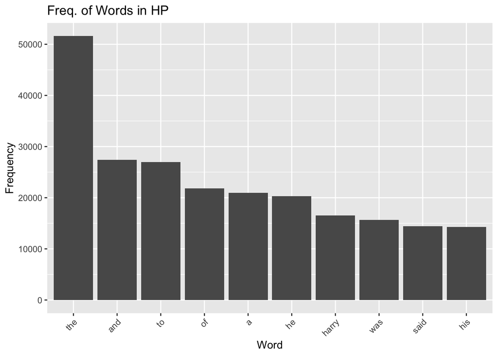

```r
wordCount %>% top_n(10) %>% ggplot(mapping = aes(reorder(word, -n),n)) + geom_col() + theme(axis.text.x=element_text(angle=45, hjust=1)) + labs(x = "Word", y = "Frequency", title = "Freq. of Words in HP")
```

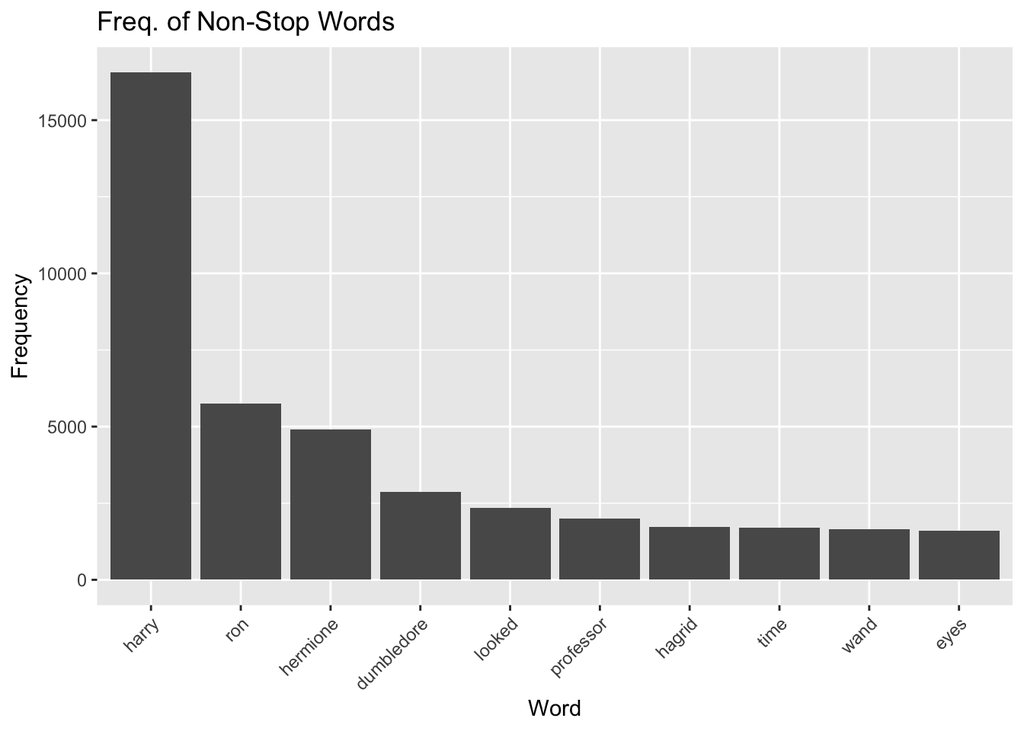

```r
series$book <- factor(series$book, levels = rev(titles))
#creating a count without filler words
nonStop<- series %>%
  anti_join(stop_words) %>%
  count(word) %>% top_n(10)

nonStop %>%
  with(ggplot(mapping = aes(reorder(word, -n),n)) + geom_col() + labs(x= "Word", y = "Frequency", title = "Freq. of Non-Stop Words") + theme(axis.text.x=element_text(angle=45, hjust=1)))
```

Now we can see that Harry and Ron are the most frequently used words. There is a phnomemna occuring in both this graph and the one preceeding. Zipf's Law states that given some corpus of natural language, the frequency of any word is inversly proportional to it's rank in the frequency table. The text of JK Rowling seems to be following this law. We can also see below that there is a similar relationship for each book.

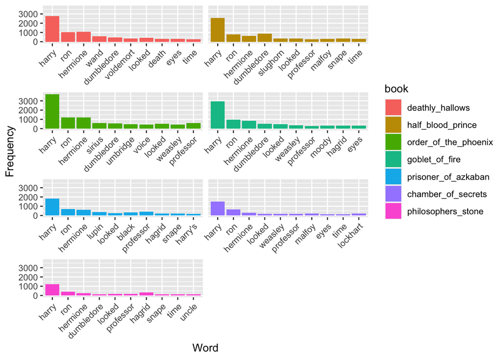

```r
series %>% group_by(book) %>% anti_join(stop_words) %>%
  count(word) %>% top_n(10) %>%
  ggplot(mapping = aes(reorder(word, -n),n, fill = book)) +
  geom_col() +
  labs(x= "Word", y = "Frequency") +
  theme(axis.text.x=element_text(angle=45, hjust=1)) +
  facet_wrap(~book, ncol=2, nrow = 4, scales = "free_x") +
  theme(strip.background = element_blank(),
  strip.text.x = element_blank()
)
```

As you can see the words that are most frequent do vary across books, due to the story line and characters.

Next I will explore the sentiment of the words using the **SentimentAnalysis** library with the function *get_sentiments*.

```r
series %>%
  anti_join(stop_words) %>%
  inner_join(get_sentiments("bing")) %>%
  count(word, sentiment, sort = TRUE)
```

```
## # A tibble: 3,278 x 3
##    word    sentiment     n
##    <chr>   <chr>     <int>
##  1 dark    negative   1034
##  2 death   negative    757
##  3 magic   positive    606
##  4 hard    negative    466
##  5 fell    negative    460
##  6 top     positive    434
##  7 fudge   negative    433
##  8 moody   negative    422
##  9 magical positive    380
## 10 dead    negative    378
## # … with 3,268 more rows
```

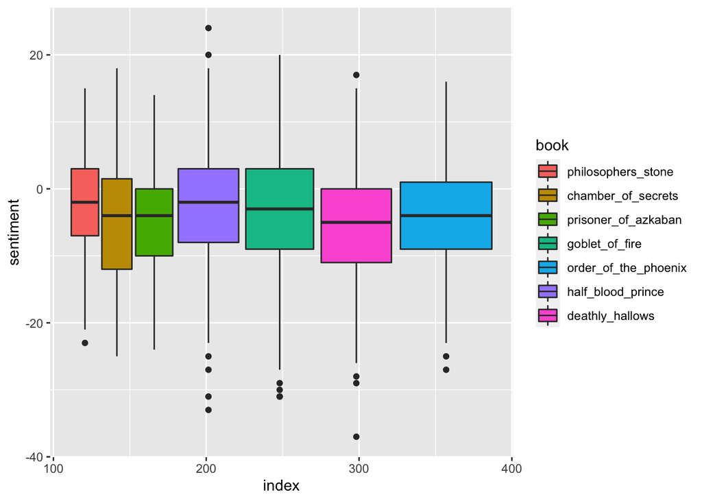

```r
series %>%
  group_by(book) %>%
  mutate(word_count = 1:n(),
         index = word_count %/% 500 + 1) %>%
  inner_join(get_sentiments("bing")) %>%
  count(book, index = index , sentiment) %>%
  ungroup() %>%
  spread(sentiment, n, fill = 0) %>%
  mutate(sentiment = positive - negative,
         book = factor(book, levels = titles)) %>%
  ggplot(aes(index, sentiment, fill = book)) +
  geom_boxplot()
```

## Appendix

https://en.wikipedia.org/wiki/Zipf%27s_law

https://rstudio-pubs-static.s3.amazonaws.com/300624_8260952d1f0346969e65f41a97006bf5.html

https://www.rpubs.com/dvdunne/reorder_ggplot_barchart_axis

https://moderndive.com/2-viz.html#geombar

https://github.com/bradleyboehmke/harrypotter

http://rstudio-pubs-static.s3.amazonaws.com/449570_fbd322569a664a139f38476a835492c1.html